# Kenya Research Report 1: Growth, Poverty and Inequality

Shaan Patel & Henrique Mittlestat

# Introduction:

One of the most prominent and upgrowing countries from the East African region is Kenya: a land of large cities, scorching suns burning the savannah grounds and the sea bathing its coast. Kenya has come a long way since its independence from the British Empire in 1963, taking up arms to fight off Somali ethnic rebels and fighting for greater political representation placing more and more African-born members on the Legislative Council, the first country to achieve such a feature back in 1944. From 1969 to 1978, Kenya was hit with a major autocratic government that neglected new elections and remained in power, the Kenyatta was a major dictator that was claimed to act in his own self-interest only; political insecurities regarding elections and corruption scandals pursued until the creation of a new constitution in 2010.

The country of Kenya is a country of sub-saharan Africa, being the 56th easiest country for conducting business according to the World Bank’s ranking , seeing great improvements since the creation of the new constitution in 2010. Scoring 1,878.581 points on GDP per capita (Current US$) in 2020 Kenya classifies as a lower-middle income country. Kenya earned 101 billion dollars in Gross Domestic Product in 2020 (Current USD), 23.05% of which comes from smallholder agricultures, 17.38% from industry mainly supported by foreign investments and 53.05% from services mainly for being a big regional transportation and financial hub, according to The National Treasury of Kenya along with data from Statista database. That being said, Kenya has a rich and diverse economy, mainly fueled by tourism, transportation hub, as mentioned, receiving over 300 million travelers for tourism and connecting flights, and the financial hub as Kenya offers great exchange and interest rates, along with liquidity ratios above international average serving as great stimulus for banking operations.

### Figure 1.0

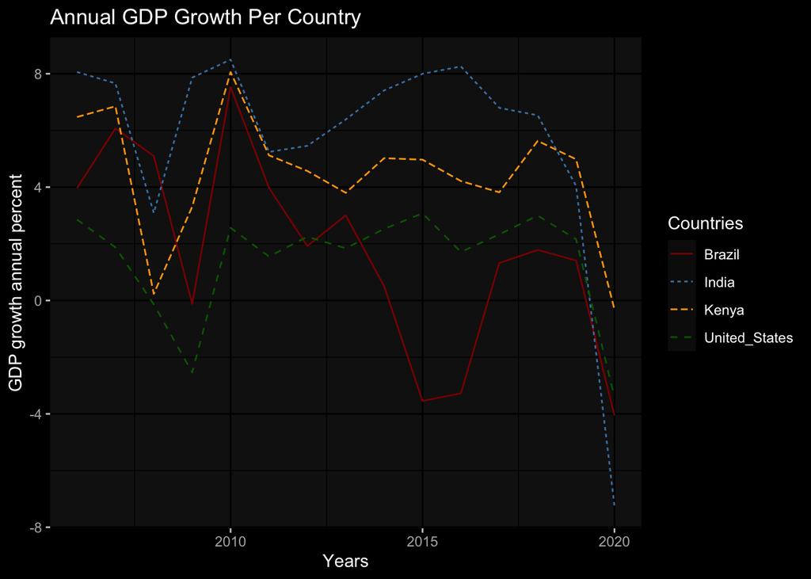

### Table 1.0

```
##      Brazil            Kenya             India        United_States
##  Min.   :-4.0590   Min.   :-0.3162   Min.   :-7.252   Min.   :-3.405
##  1st Qu.: 0.1891   1st Qu.: 3.8067   1st Qu.: 5.349   1st Qu.: 1.631
##  Median : 1.7837   Median : 4.9677   Median : 6.795   Median : 2.161
##  Mean   : 1.7047   Mean   : 4.4480   Mean   : 5.735   Mean   : 1.444
##  3rd Qu.: 3.9682   3rd Qu.: 5.3751   3rd Qu.: 7.929   3rd Qu.: 2.545
##  Max.   : 7.5282   Max.   : 8.0585   Max.   : 8.498   Max.   : 3.076
```

## Growth & Development

The Real GDP growth timing from March 2010 to March 2020 in Kenya has an average rate of 5.5%, having reached an all time high in March 2011 of 13.6% one year after the new constitution. The increase in growth rate took shape after the formulation of the Vision 2030 development plan, a long-term development project created in 2007 which directly aligns itself with the Millennium Development Goals, drawing . Vision 2030 is a plan made up of four MTP’s (medium-term plans) that will set policies for economic development and each one is to be in effect over a 5-year period. The first MTP was designed to reduce violence and clashes within the population, increasing security and economic optimism; the second MTP aimed to develop the economy in a certain way to reduce poverty, hunger, increase education and provide improved infrastructures in water sources covering over half of the Millenium Development Goals. The MTP currently in effect is the third one, since 2017 and ending this year of 2022, aims to create inclusions across genders enhancing equality and increase industrial share of contribution to the GDP providing the population with better payment increasing GDP per capita and average income. Unfortunately, the world was hit with a pandemic that breaked Kenya’s growth in 2020, however, they were able to maintain the GDP nearly constant, decreasing by only 0.3%, which indicates good economic management during the first year of the COVID-19 pandemic. Their resilience during 2020 granted them a loan through the International Monetary Fund granted them a $2.34 billion dollars loan in 2021 through ECF and EFF, Extended Credit Facility and Extended Fund Facility respectively, projecting a growth of 5.7% (2022) and 6.1% (2023)

### Figure 2.0

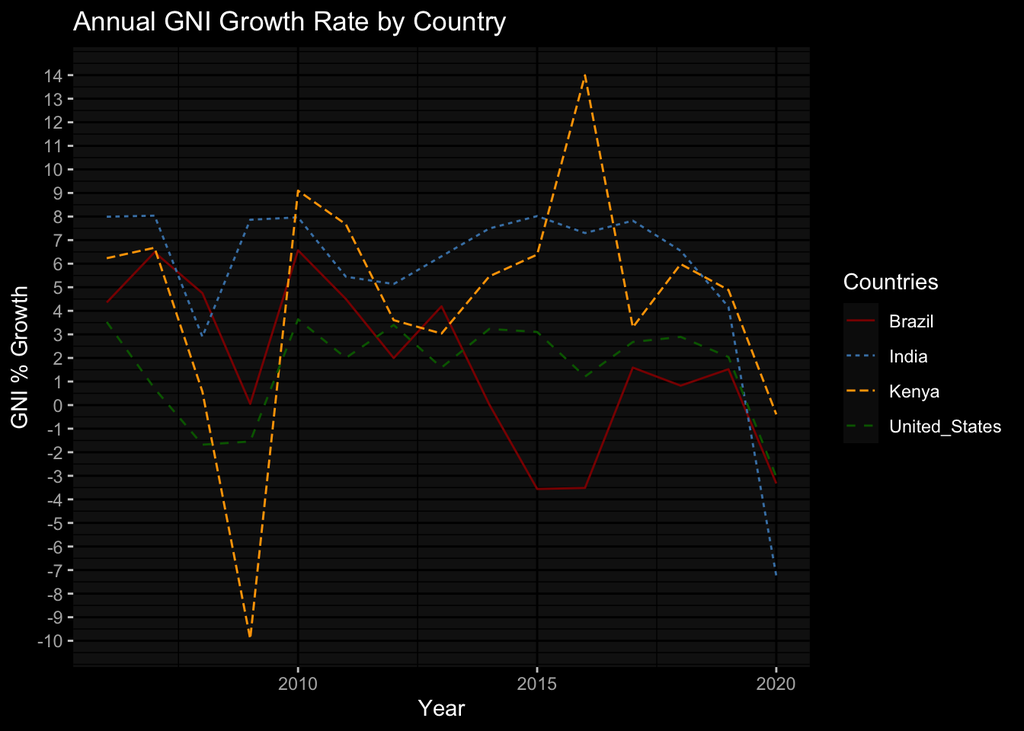

### Table 2.0

```
##      Brazil             Kenya            India        United_States
##  Min.   :-3.56013   Min.   :-9.919   Min.   :-7.246   Min.   :-3.0451
##  1st Qu.: 0.03752   1st Qu.: 3.168   1st Qu.: 5.292   1st Qu.: 0.9573
##  Median : 1.59150   Median : 5.464   Median : 7.299   Median : 2.0421
##  Mean   : 1.76404   Mean   : 4.439   Mean   : 5.717   Mean   : 1.5835
##  3rd Qu.: 4.42894   3rd Qu.: 6.531   3rd Qu.: 7.914   3rd Qu.: 3.1674
##  Max.   : 6.56692   Max.   :13.994   Max.   : 8.038   Max.   : 3.6411
```

In figure 2.0, the GNI growth for Kenya declined 9.92 % during the crash of 2007-2008. Kenya suffered the worst on average during the US financial crisis, but also rebounded the most, having a growth rate of about 20% between 2008 and 2010. At this time Kenya’s government formed a task force in line with the new 2010 constitution to look into ways to cushion their economy from the effects of the financial crisis. Kenya decided to open up their markets to the United States and other developing countries to grow their economy which is different from Brazil’s approach after the crisis. Kenya is an outlier in this situation where GNI is growing faster than Brazil and the United States combined on average almost with as much average growth as India. In 2015, Kenya had opened up their markets to the United States, China and expanded their influence in African markets, which allowed them to experience a short-term influx of growth in GNI. This is around the time when Kenya unveiled their second medium term plans of focusing on rapid economic growth in a stable macroeconomic environment. This was intended to help achieve modernisation of Kenya’s infrastructure, diversification and commercialization of agriculture, and higher contributions of manufacturing to GDP. This contributed to Kenya being able to increase GNI growth rate dramatically. But you can quickly see that the plans were short-term because when all countries approached 2020 the growth in GNI declined dramatically. This is in effect of short-term growth plans and why GNI growth in Kenya had been affected negatively because it cannot be seen as a trend. This is attributed to Kenya and it’s outliered growth rates in 2008 and 2015 where Kenya has experienced the most variance in their GNI growth due to the instability in the government’s foriegn policy decisions in relation to their economy’s connection to the global markets.

### Figure 3.0

[figure not shown]

## Poverty Headcount ratio and Income Inequality

### Figure 4.0

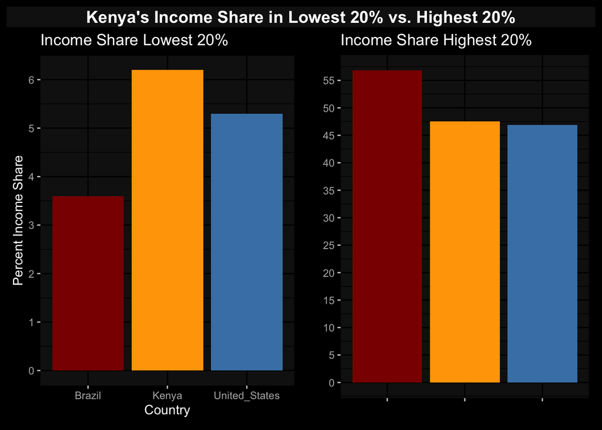

Figure 4.0 demonstrates that Kenya and the United States have similar income shares for both, lowest and highest 20%. On the other hand, they have very different economies with different average incomes. The high shares of income for the highest 20% is given due the rising of multibillionaires in 2015, and, the GNI per capita is also directly correlated with the graph which demonstrates that even with similar shares of income for both data translates for different living standards. Brazil is an outlier in the graph, for it has a very large GNI, yet much more radical income shares, this demonstrates that the lowest 20%, associated with the GNI per capita for Brazil and Kenya, means that the poor may have very similar living standards when comparing these two countries. On the other hand, Kenya’s medium-term plans for inclusion and equality development should produce an outcome where income inequality is not as spread and poverty headcount ratio decreases for when it is analyzed again in 2025, since the research is done every 10 years.

# Closing Summary

The country of Kenya itself is an outlier of the African continent, with GDP and GNI well above the majority of the countries that constitute the region, including the neighboring countries. It has been the first country to include African members to its parliament and to include women in politics, that also associated with being one of the most advanced countries from East Africa sets it as an example for other nations to follow.

It has demonstrated many attempts to stabilize its economy and political unrestness with new constitutions and policy plans - known as MTPs - to better develop the country, making Kenya more susceptible to receive financial aid and form global partnerships, making it the closest country to achieving the Millennium Development Goals in the continent.

During hardships, such as the US financial crisis and COVID-19, the nation has demonstrated great resilience during times of crisis, which could be a strong indicator of the population and the politics coming together to transform Kenya into a first world country. This huge indicator of commitment is optimistic, yet, there are many aspects that need to be enhanced for Kenya still to become an even greater nation. It is of urgency that they focus on promoting more equality in income distribution and derive efforts to reduce headcount ratio and increase schooling before it can advance into a developed country status.

That being said, Kenya is a country with immense potential, and growing, as they diversify the economy and try to shift their main income to manufacturing areas, they will be able to apply technical change more efficiently. It isn’t impossible to expect from Kenya that they reach their goals from the project Vision 2030 in achieving greater equality and living standards. There is much to learn from how much effort Kenya is placing in developing itself and it isn’t crazy to expect that Kenya might yet to become the most developed country in the African continent.

# Refrences

—Ease of Doing Business Rank (1=Most Business-Friendly Regulations) - Kenya.” Data, https://data.worldbank.org/indicator/IC.BUS.EASE.XQ?locations=KE&most_recent_value_desc=false.

—“Economic Growth and Trade: Kenya.” U.S. Agency for International Development, 1 Mar. 2022, https://www.usaid.gov/kenya/economic-growth-and-trade.

—“Home.” The National Treasury - The National Treasury of Kenya, https://www.treasury.go.ke/kenya-economy/. “Human Development Reports.” | Human Development Reports, https://hdr.undp.org/en/composite/trends.

—“IMF Executive Board Approves US$2.34 Billion ECF and EFF Arrangements for Kenya.” IMF, 2 Apr. 2021, https://www.imf.org/en/News/Articles/2021/04/02/pr2198-kenya-imf-executive-board-approves-us-billion-ecf-and-eff-arrangements. Kenya - Hdr.dev.undp.org. http://hdr.dev.undp.org/sites/default/files/Country-Profiles/MPI/KEN.pdf.

—“Kenya Declares Independence from Britain.” History.com, A&E Television Networks, 8 Aug. 2019, https://www.history.com/this-day-in-history/kenya-declares-independence-from-britain#:~:text=On%20December%2012%2C%201963%2C%20Kenya,had%20shaken%20the%20British%20colony.

—O’Neill, Aaron. “Kenya - Share of Economic Sectors in the Gross Domestic Product 2020.” Statista, 15 Feb. 2022, https://www.statista.com/statistics/451143/share-of-economic-sectors-in-the-gdp-in-kenya/#:~:text=This%20statistic%20shows%20the%20share,sector%20contributed%20about%2053.56%20percent.

—“World Development Indicators.” DataBank, https://databank.worldbank.org/source/world-development-indicators#.

—“World War II to Independence.” Encyclopædia Britannica, Encyclopædia Britannica, Inc., https://www.britannica.com/place/Kenya/World-War-II-to-independence.